# Power Analyses

Matteo Lisi, Erin Buchanan

2024-10-25

## Libraries

```r
library(tidyverse)
library(lme4)
```

## Command Arguments

The power analyses script `power-script-cluster.R` is designed to be run via Rscript in command line and receive some parameters as input.

You would use `PSAsubmit.sh` on the command line that runs `PSA_sim_wrapper.sh`, sending the variable settings to `power-script-cluster.R`.

The simulation variable settings are as follow:

`N` = # of participants sampled, anywhere from 25-250 per simulation `N_c` = # of countries sampled, anywhere from 30-50 per simulation `N_rep` = # of repetitions for the sample simulations `wratio` = fraction of countries in one cultural category `iteration` = the simulation label for saving files

```r
N <- seq(from = 25, by = 25, to = 250)
N_c <- seq(from = 30, by = 2, to = 50)
N_rep <- 50
wratio <- 0.5 # used .3, .4, .5 ran separately
iteration <- c("A", "B", "C", "D", "E", "F", "G", "H")
```

The values for these are set in the `PSAsubmit.sh` bash script:

```
#!/bin/bash
# File: PSAsubmit.sh

# Generate the sequences for $1 and $2 using seq command in bash
N = $(seq 25 25 250)
N_c = $(seq 30 2 50)
wratio = 0.5
N_rep = 50
iteration = "A B C D E F G H"


# Iterate over the values for $1, $2 and iteration
for val1 in $N
do
 for val2 in $N_c
 do
 for letter in $iteration
 do
  # Submit the job with current values
  qsub PSA_sim_wrapper.sh $val1 $val2 $N_rep $wratio $letter
 done
 done
done
```

## Parameter Settings

The first part of the power simulation script consists the setting of key simulation parameters:

- `err_mu` and `err_sd` are the mean and SD across participants of error rates (probability of answering a CRT problem incorrectly in the first intuitive phase), expressed in a log-odds scale
- `corr_mu`, and `corr_sd` are mean and SD across participants of correction rates - that is the probability that an error in the first intuitive phase is corrected in the second deliberative phase (see manuscript for details of the method)
- `beta_lo_p` represented differences in correction rates between each condition [feedback, justification, both] relative to the baseline condition
- `n_trial` is set to 6 as we have 6 CRT problems in the study

```r
# these are plausible parameter values based on Sirota 2023 and similar
# article in the literature

# p(error @ stage 1)
err_mu <- 1.22
err_sd <- 0.92

# p(correct @ stage 2 | error @ stage 1)
corr_mu <- -2.53
corr_sd <- 1.12

# set effect sizes ----

# Set effect values in standardized as Cohen's d and rescale
# to an approximately similar value for the logistic distribution.
# Specifically, we multiply the d values by the ratio of the standard deviation
# of the logistic distribution to that of the standard normal distribution,
# which is (pi/sqrt(3)).
d_fdbk <- 0.19 * (pi/sqrt(3)) # feedback minus baseline
d_just <- 0.19 * (pi/sqrt(3)) # justification minus baseline
d_both <- (d_fdbk + d_just) # (feedback + justification) minus baseline
# Note: we expect the effects of feedback to be additive

# vector of fixed-effects coefficients
beta_lo_p <- c(corr_mu, NA, NA, NA)
beta_lo_p[2] <- d_fdbk
beta_lo_p[3] <- d_just
beta_lo_p[4] <- d_both

# determine the country-level random effect SD
# half the group-level effect size, so that ~95% of countries have
# population-level effects of the same sign
rfx_sd_country <- (0.19 * (pi/sqrt(3))) / 2

# power simulation parameters ----
n_trial <- 6
```

## Generate Data Function

```r
# data simulation function
gen_data <- function(N, N_c, wratio){

 N_tot <- N * N_c * 4 # 4 is the number of between subjects conditions

 ## simulate dataset
 # simulate error propensity of individual participants in phase 1
 # simulate number of errors in phase 1
 # number of errors (log(errors))
 error_lo <- rnorm(N_tot, mean = err_mu, sd = err_sd)

 # simulate random effects and between-individual variability
 # (to introduce heterogeneity and make simulations more realistic)
 rfx_id <- rnorm(N_tot, mean = 0, sd = corr_sd)

 # sample countries
 rfx_country <- rnorm(N_c, mean = 0, sd = rfx_sd_country)
 group_country <- generate_labels(N_c, wratio)

 # create dataset frame
 dat <- expand_grid(country = 1:N_c,
   condition = 1:4,
   id = 1:N,
   trial = 1:6) %>%
 mutate(id = str_c(id, country, condition, sep = "_"))
 dat$country_group <- group_country[dat$country]

 # simulate responses
 dat$corrected <- NA
 dat$error <- NA
 dat$id <- as.integer(factor(dat$id, labels = 1:length(unique(dat$id))))
 dat$lo <- NA
 dat$error_lo <- error_lo[dat$id]
 dat$rfx_country <- rfx_country[dat$country]
 dat$rfx_id <- rfx_id[dat$id]

 # set log-odds of p(correction) for each datapoint
 dat <- dat %>%
 # control group, baseline who don't get anything (beta_lo_p[1])
 # intercept (control group mean because X1 is the group they are in)
 # intercept beta_lo_p[1] + group*0 + country random + person random effect
 mutate(lo = beta_lo_p[1] + rfx_country + rfx_id) %>%
 mutate(lo = case_when(
 # when group 1 baseline keep the original estimation from the line above
 condition == 1 ~ lo,
 # when group is not baseline (feedback, justification, both) then add in the effect of those other conditions
 condition == 2 ~ lo + beta_lo_p[2],
 condition == 3 ~ lo + beta_lo_p[3],
 condition == 4 ~ lo + beta_lo_p[4]
 ))

 # simulate number of errors likely for participants
 dat$error <- rbinom(nrow(dat),
   size = 1,
   p = exp(dat$error_lo)/(1 + exp(dat$error_lo)))

 # simulate number of errors that are corrected in phase 2
 dat$corrected <- ifelse(dat$error == 1,
    rbinom(nrow(dat),
     size = 1,
     p = exp(dat$lo)/(1 + exp(dat$lo))),
    0)

 # total correct responses given the simulated data
 dat$correct <- 1-dat$error + dat$corrected

 # keep only trials with errors in phase 1
 dat <- dat %>%
 # filter(error == 1) %>%
 mutate(c_F = ifelse(condition == 2, 1, 0),
  c_FR = ifelse(condition == 3, 1, 0)) %>%
 mutate(feedback = ifelse(condition == 2 | condition == 4, 1, 0),
  justification = ifelse(condition == 3 | condition == 4, 1, 0),
  condition = case_when(
  condition == 1 ~ "baseline",
  condition == 2 ~ "feedback",
  condition == 3 ~ "justification",
  condition == 4 ~ "feedback + justification"
  ))

 dat$country_group <- factor(dat$country_group)

 # Set attributes
 attr(dat, "N") <- N
 attr(dat, "N_c") <- N_c

 # return simulated data
 return(dat)
}
```

Note that the function above calls also this other function to generate a set of labels `weird`/`non-weird` to allocate the simulated countries in one cultural category or the other randomly.

```r
# country grouping labels
generate_labels <- function(N_c, wratio = 0.5) {
 n_weird <- round(wratio * N_c)
 n_nonweird <- N_c - n_weird
 labels <- c(
 rep("weird", n_weird),
 rep("non-weird", n_nonweird)
 )[sample(N_c)]
 return(labels)
}
```

## Test Hypotheses Function

The function below test all the hypotheses as outlined in the manuscript. Note that the dependent variable is slightly different for H1a and H1b compared to the other hypotheses. Specifically, for hypotheses H1A and H1B the variable of interest is the proportion of correct responses made in phase 2 (out of all correct responses given in phase 1 and 2); in set notation, this would be $\frac{|C_2 \setminus C_1|}{|C_1 \cup C_2|}$ where $C_1$ and $C_2$ are the items correctly answered in phase 1 and 2, respectively.

For the remaining hypotheses, the variable of interest is the probability that participants correct their errors in phase 2; in set notation this would be $\frac{|E_1 \cap C_2|}{|E_1|}$, where $E_1$ indicate the items incorrectly answered in phase 1.

```r
test_hypotheses <- function(dat){

 require(lme4)
 # dat <- gen_data(100, 30, 0.6)

 dat_H1 <- dat %>%
 filter(correct == 1)

 dat <- dat %>%
 filter(error == 1)

 ## FIT MODELS

 # fit overall model
 m_all <- glmer(corrected ~ feedback * justification +
   (feedback * justification||country),
   family = binomial("logit"),
   data = dat,
   control = glmerControl(optimizer = "bobyqa",
     optCtrl = list(maxfun = 1e5)))

 # fit country_group-level models for weird and non-weird
 m_w <- glmer(corrected ~ feedback * justification +
   (feedback * justification||country),
  family = binomial("logit"),
  data = dat[dat$country_group == "weird", ],
  control = glmerControl(optimizer = "bobyqa",
     optCtrl = list(maxfun = 1e5)))

 m_nw <- glmer(corrected ~ feedback * justification +
   (feedback * justification||country),
  family = binomial("logit"),
  data = dat[dat$country_group == "non-weird", ],
  control = glmerControl(optimizer = "bobyqa",
     optCtrl = list(maxfun = 1e5)))


 # now fit models for H1 specifically: note that here the dependent
 # variable is different as the hypothesis is about the proportion of
 # correct response (out of all correct responses) that are corrected
 # in phase 2 ('data' arguments is set to 'dat_H1' instead of just 'dat')
 #
 mH1_all <- glmer(corrected ~ feedback * justification +
   (feedback * justification||country),
   family = binomial("logit"), data = dat_H1,
   control = glmerControl(optimizer = "bobyqa",
      optCtrl = list(maxfun = 1e5)))

 # fit country_group-level models for weird and nonweird
 mH1_w <- glmer(corrected ~ feedback * justification +
   (feedback * justification||country),
   family = binomial("logit"),
   data = dat_H1[dat_H1$country_group == "weird", ],
   control = glmerControl(optimizer = "bobyqa",
     optCtrl = list(maxfun = 1e5)))

 mH1_nw <- glmer(corrected ~ feedback * justification +
   (feedback * justification||country),
   family = binomial("logit"),
   data = dat_H1[dat_H1$country_group == "non-weird", ],
   control = glmerControl(optimizer = "bobyqa",
      optCtrl = list(maxfun = 1e5)))


 ## TEST HYPOTHESES

 alpha <- 0.05
 # note: the tests on separate country_groups are independent one another
 # (different countries, participants, labs, etc.), so the expected
 # false positive rate of the composite test, run on the 2 country_group
 # separately and using the conventional alpha = 0.05 for each test,
 # would be 0.05^2 = 0.0025 (the hypothesis supported if and only if
 # all 2 independent tests are significant). We don't also apply correction
 # for multiple comparisons otherwise it would become too conservative.

 # -----------
 # H1
 # # p_correction < 0.5

 # One-tailed test for H1a
 # Testing if the intercept is significantly less than 0
 b_H1a <- fixef(mH1_all)["(Intercept)"]
 SE_H1a <- sqrt(diag(vcov(mH1_all))["(Intercept)"])
 z_H1a <- b_H1a / SE_H1a
 p_value_H1a <- pnorm(z_H1a) # left-tailed test
 H1a <- ifelse(p_value_H1a < alpha, 1, 0)

 # One-tailed tests for H1b
 models <- list(mH1_w, mH1_nw)
 names <- c("weird", "non-weird")
 H1b_pvals <- numeric(length(models))
 H1b_results <- numeric(length(models))

 for (i in 1:length(models)) {
 b <- fixef(models[[i]])["(Intercept)"]
 SE <- sqrt(diag(vcov(models[[i]]))["(Intercept)"])
 z <- b / SE
 p_value <- pnorm(z) # left-tailed test
 H1b_pvals[i] <- p_value
 H1b_results[i] <- ifelse(p_value < alpha, 1, 0)
 }

 names(H1b_pvals) <- names
 names(H1b_results) <- names

 # complete test
 H1b <- ifelse(all(H1b_results == 1), 1, 0)

 # -----------
 # H2

 # feedback increases correction rate

 # One-tailed test for H2a
 # Testing if the coefficient for 'feedback' is significantly greater than 0
 b_H2a <- fixef(m_all)["feedback"]
 SE_H2a <- sqrt(diag(vcov(m_all))["feedback"])
 z_H2a <- b_H2a / SE_H2a
 p_value_H2a <- 1 - pnorm(z_H2a) # right-tailed test
 H2a <- ifelse(p_value_H2a < alpha, 1, 0)

 # One-tailed tests for H2b
 models <- list(m_w, m_nw)
 names <- c("weird", "non-weird")
 H2b_pvals <- numeric(length(models))
 H2b_results <- numeric(length(models))

 for (i in 1:length(models)) {
 b <- fixef(models[[i]])["feedback"]
 SE <- sqrt(diag(vcov(models[[i]]))["feedback"])
 z <- b / SE
 p_value <- 1 - pnorm(z) # right-tailed test
 H2b_pvals[i] <- p_value
 H2b_results[i] <- ifelse(p_value < alpha, 1, 0)
 }

 names(H2b_pvals) <- names
 names(H2b_results) <- names

 # complete test
 H2b <- ifelse(all(H2b_results == 1), 1, 0)

 # -----------
 # H3

 # justification increases correction rate

 # One-tailed test for H3a
 # Testing if the coefficient for 'justification' is significantly greater than 0
 b_H3a <- fixef(m_all)["justification"]
 SE_H3a <- sqrt(diag(vcov(m_all))["justification"])
 z_H3a <- b_H3a / SE_H3a
 p_value_H3a <- 1 - pnorm(z_H3a) # right-tailed test
 H3a <- ifelse(p_value_H3a < alpha, 1, 0)

 # One-tailed tests for H3b
 models <- list(m_w, m_nw)
 names <- c("weird", "non-weird")
 H3b_pvals <- numeric(length(models))
 H3b_results <- numeric(length(models))

 for (i in 1:length(models)) {
 b <- fixef(models[[i]])["justification"]
 SE <- sqrt(diag(vcov(models[[i]]))["justification"])
 z <- b / SE
 p_value <- 1 - pnorm(z) # right-tailed test
 H3b_pvals[i] <- p_value
 H3b_results[i] <- ifelse(p_value < alpha, 1, 0)
 }

 names(H3b_pvals) <- names
 names(H3b_results) <- names

 # complete test
 H3b <- ifelse(all(H3b_results == 1), 1, 0)


 # save results -----------

 # retrieve settings
 N <- attr(dat, "N")
 N_c <- attr(dat, "N_c")
 N_tot <- N * N_c * 4

 d_line <- data.frame(N_per_condition = N,
   N_tot = N_tot,
   N_countries = N_c,
   H1a, H1b,
   H2a, H2b,
   H3a, H3b)

 return(d_line)

}
```

## Test It

If you want to test how this code works, here’s an example:

```r
N <- 25
N_c <- 30
wratio <- 0.5

d_line <- test_hypotheses(gen_data(N, N_c, wratio))
d_line
```

```
##             N_per_condition N_tot N_countries H1a H1b H2a H2b H3a H3b
## (Intercept)              25  3000          30   1   1   1   1   1   1
```

## Results

```r
folder_path <- "results"
csv_files <- list.files(path = folder_path,
   pattern = "*.csv",
   full.names = TRUE)
d <- bind_rows(lapply(csv_files, read.csv))
```

We have already combined several runs of the simulations in the file `power_sim_results.csv`

```r
d <- read_csv("power_sim_results.csv")
str(d)
```

```
## spc_tbl_ [54,000 × 10] (S3: spec_tbl_df/tbl_df/tbl/data.frame)
##  $ N_per_condition : num [1:54000] 100 100 100 100 100 100 100 100 100 100 ...
##  $ N_tot           : num [1:54000] 12000 12000 12000 12000 12000 12000 12000 12000 12000 12000 ...
##  $ N_countries     : num [1:54000] 30 30 30 30 30 30 30 30 30 30 ...
##  $ H1a             : num [1:54000] 1 1 1 1 1 1 1 1 1 1 ...
##  $ H1b             : num [1:54000] 1 1 1 1 1 1 1 1 1 1 ...
##  $ H2a             : num [1:54000] 1 1 1 1 1 1 1 1 1 1 ...
##  $ H2b             : num [1:54000] 1 1 1 1 1 1 1 1 1 1 ...
##  $ H3a             : num [1:54000] 1 1 1 1 1 1 1 1 1 1 ...
##  $ H3b             : num [1:54000] 1 1 1 1 1 1 1 1 1 1 ...
##  $ smaller_fraction: num [1:54000] 0.5 0.5 0.5 0.5 0.5 0.5 0.5 0.5 0.5 0.5 ...
##  - attr(*, "spec")=
##   .. cols(
##   ..   N_per_condition = col_double(),
##   ..   N_tot = col_double(),
##   ..   N_countries = col_double(),
##   ..   H1a = col_double(),
##   ..   H1b = col_double(),
##   ..   H2a = col_double(),
##   ..   H2b = col_double(),
##   ..   H3a = col_double(),
##   ..   H3b = col_double(),
##   ..   smaller_fraction = col_double()
##   .. )
##  - attr(*, "problems")=<externalptr>
```

Here `smaller_fraction` is an additional variable that correspond to the fraction of countries in the smaller category, which was added when the results were compiled to identify runs with different values of `wratio`. Below we report code and plots of estimated power separately for 50-50, 60-40 and 70-30 splits of countries in cultural categories.

For the plots, binomial standard errors for each set of simulations are computed with:

```r
binomSEM <- function (v) {
 sqrt((mean(v) * (1 - mean(v)))/length(v))
}
```

### 50-50

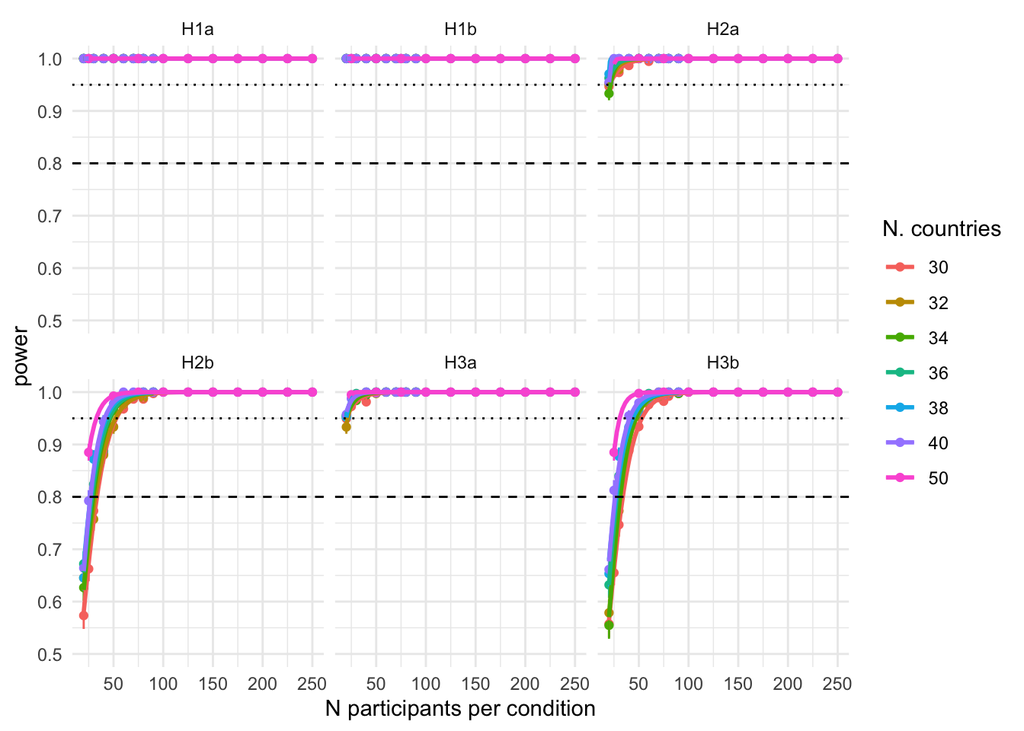

```r
# smaller_fraction ratio
ratio_small <- 0.5

# Reshape the data
data_long <- d %>%
 filter(smaller_fraction == ratio_small) %>%
 gather(key = "hypothesis", value = "value", starts_with("H")) %>%
 filter(!is.na(value))

# create an average data by total N, N per condition,
# countries, and hypotheses
data_long_avg <- data_long %>%
 group_by(N_tot, N_per_condition, N_countries, hypothesis) %>%
 summarise(
 se_value = binomSEM(value),
 value = mean(value)
 )

# plot split according to number of countries
ggplot(data_long, aes(x = N_per_condition,
   y = value, color = as.factor(N_countries))) +
 geom_point(data = data_long_avg) +
 geom_errorbar(data = data_long_avg,
  aes(ymin = value-se_value, ymax = value + se_value), width = 0) +
 geom_smooth(method = "glm",
  method.args = list(family = "binomial"), se = FALSE) +
 facet_wrap(~hypothesis) +
 labs(color = "N. countries", x = "N participants per condition", y = "power") +
 geom_hline(yintercept = 0.8, lty = 2) +
 geom_hline(yintercept = 0.95, lty = 3) +
 coord_cartesian(ylim = c(0.5, 1)) +
 theme_minimal()
```

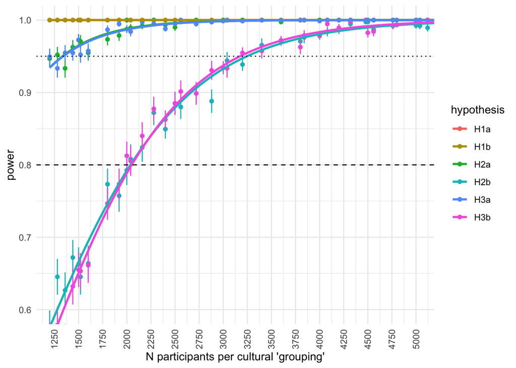

```r
# plot only as a function of number of participants
data_long_avg2 <- data_long %>%
 mutate(N_per_grouping = ratio_small* N_tot) %>%
 group_by(N_per_grouping, hypothesis) %>%
 summarise(
 se_value = binomSEM(value),
 value = mean(value)
 )

# add n per group to the data
data_long <- data_long %>%
 mutate(N_per_grouping = ratio_small * N_tot)

# plot of n per group
ggplot(data_long, aes(x = N_per_grouping,
                      y = value, color = hypothesis, group = hypothesis)) +
 geom_point(data = data_long_avg2) +
 geom_errorbar(data = data_long_avg2,
               aes(ymin = value-se_value, ymax = value + se_value), width = 0) +
 geom_smooth(method = "glm",
             method.args = list(family = "binomial"), se = FALSE, n = 500) +
 labs(x = "N participants per cultural 'grouping'", y = "power") +
 geom_hline(yintercept = 0.8, lty = 2) +
 geom_hline(yintercept = 0.95, lty = 3) +
 coord_cartesian(ylim = c(0.6, 1), xlim = c(1250, 5000)) +
 scale_x_continuous(breaks = seq(0, 10000, 250),
                    guide = guide_axis(angle = 90)) +
 theme_minimal()
```

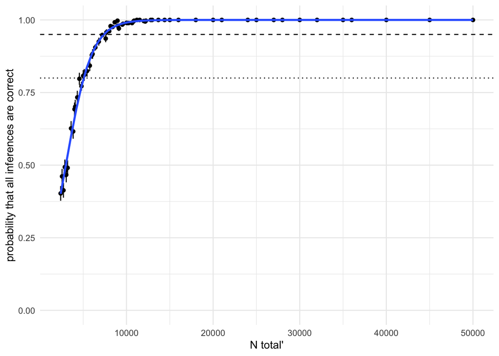

```r
## plot p(all inferences correct)
d$value <- ifelse(d$H1a + d$H1b + d$H2a + d$H2b + d$H3a + d$H3b == 6, 1, 0)

data_avg2 <- d %>%
 filter(smaller_fraction == ratio_small) %>%
 group_by(N_tot) %>%
 summarise(
 se_value = binomSEM(value),
 value = mean(value)
 )

d %>%
 filter(smaller_fraction == ratio_small) %>%
 ggplot(aes(x = N_tot, y = value)) +
 geom_point(data = data_avg2) +
 geom_errorbar(data = data_avg2,
               aes(ymin = value-se_value, ymax = value + se_value), width = 0) +
 geom_smooth(method = "glm",
             method.args = list(family = "binomial"), se = FALSE) +
 geom_hline(yintercept = 0.95, lty = 2) +
 geom_hline(yintercept = 0.8, lty = 3) +
 coord_cartesian(ylim = c(0, 1)) +
 labs(x = "N total'", y = "probability that all inferences are correct") +
 theme_minimal()
```

### 60-40

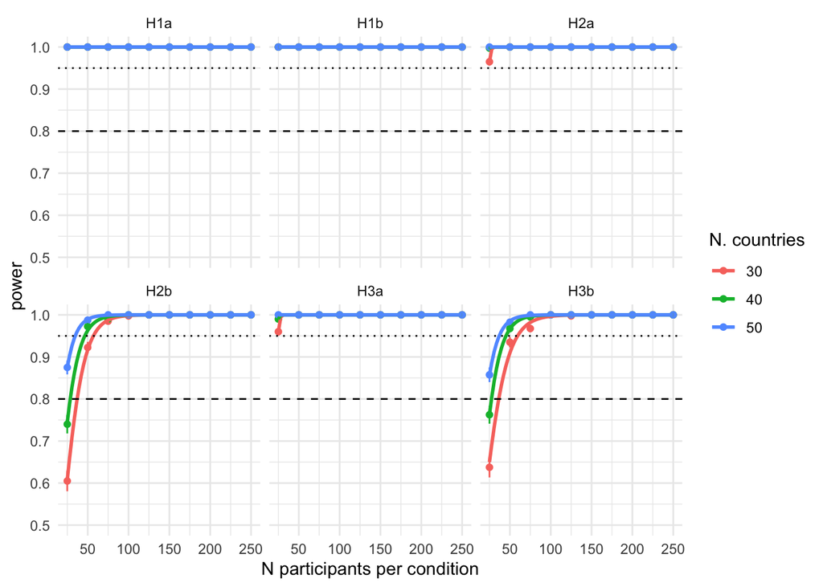

```r
# see descriptions above
ratio_small <- 0.4

# Reshape the data
data_long <- d %>%
 filter(smaller_fraction == ratio_small) %>%
 gather(key = "hypothesis", value = "value", starts_with("H")) %>%
 filter(!is.na(value))

data_long_avg <- data_long %>%
 group_by(N_tot, N_per_condition, N_countries, hypothesis) %>%
 summarise(
 se_value = binomSEM(value),
 value = mean(value)
 )

# plot split according to number of countries
ggplot(data_long, aes(x = N_per_condition,
                      y = value, color = as.factor(N_countries))) +
 geom_point(data = data_long_avg) +
 geom_errorbar(data = data_long_avg,
               aes(ymin = value-se_value, ymax = value + se_value), width = 0) +
 geom_smooth(method = "glm",
             method.args = list(family = "binomial"), se = FALSE) +
 facet_wrap(~hypothesis) +
 labs(color = "N. countries", x = "N participants per condition", y = "power") +
 geom_hline(yintercept = 0.8, lty = 2) +
 geom_hline(yintercept = 0.95, lty = 3) +
 coord_cartesian(ylim = c(0.5, 1)) +
 theme_minimal()
```

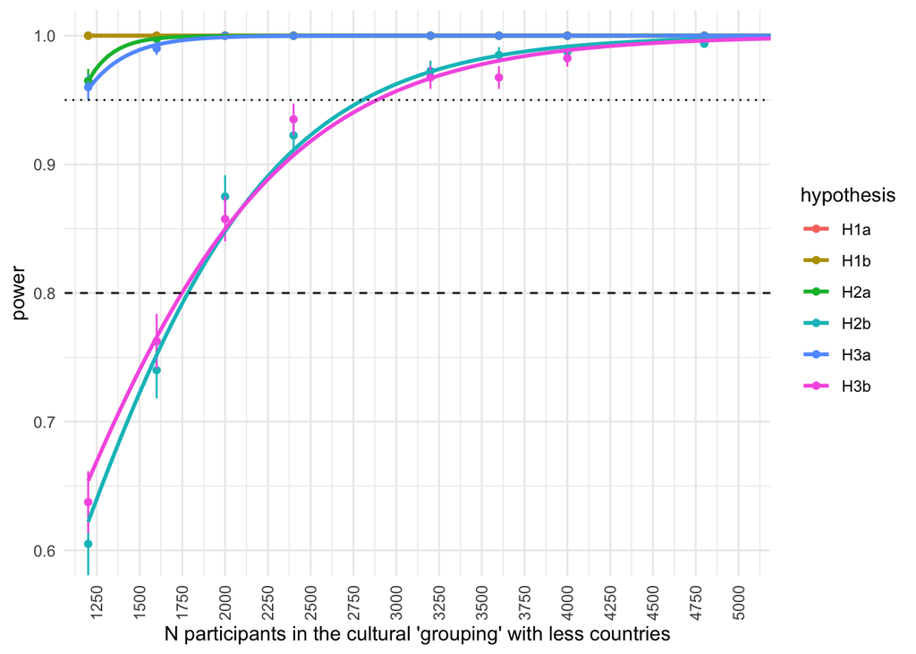

```r
# plot only as a function of number of participants
data_long_avg2 <- data_long %>%
 mutate(N_per_grouping = ratio_small* N_tot) %>%
 group_by(N_per_grouping, hypothesis) %>%
 summarise(
 se_value = binomSEM(value),
 value = mean(value)
 )

data_long <- data_long %>%
 mutate(N_per_grouping = ratio_small* N_tot)

ggplot(data_long, aes(x = N_per_grouping,
                      y = value, color = hypothesis, group = hypothesis)) +
 geom_point(data = data_long_avg2) +
 geom_errorbar(data = data_long_avg2,
               aes(ymin = value-se_value, ymax = value + se_value), width = 0) +
 geom_smooth(method = "glm",
             method.args = list(family = "binomial"), se = FALSE, n = 500) +
 labs(x = "N participants in the cultural 'grouping' with less countries", y = "power") +
 geom_hline(yintercept = 0.8, lty = 2) +
 geom_hline(yintercept = 0.95, lty = 3) +
 coord_cartesian(ylim = c(0.6, 1), xlim = c(1250, 5000)) +
 scale_x_continuous(breaks = seq(0, 10000, 250),
                    guide = guide_axis(angle = 90)) +
 theme_minimal()
```

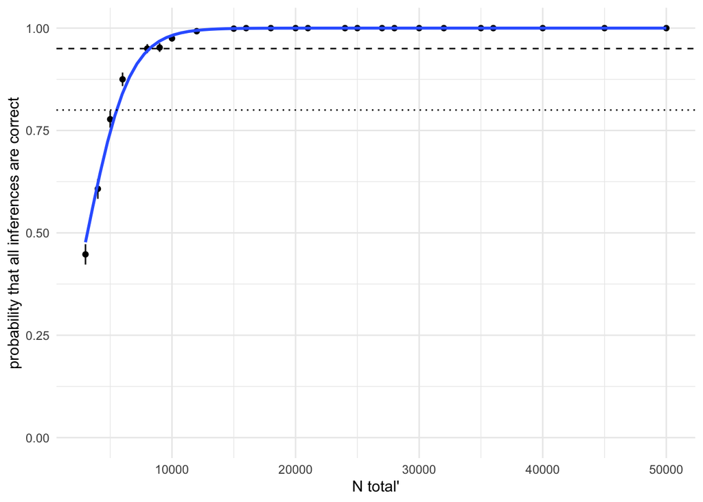

```r
## plot p(all inferences correct)
d$value <- ifelse(d$H1a + d$H1b + d$H2a + d$H2b + d$H3a + d$H3b == 6, 1, 0)

data_avg2 <- d %>%
 filter(smaller_fraction == ratio_small) %>%
 group_by(N_tot) %>%
 summarise(
 se_value = binomSEM(value),
 value = mean(value)
 )

d %>%
 filter(smaller_fraction == ratio_small) %>%
 ggplot(aes(x = N_tot, y = value)) +
 geom_point(data = data_avg2) +
 geom_errorbar(data = data_avg2,
               aes(ymin = value-se_value, ymax = value + se_value), width = 0) +
 geom_smooth(method = "glm",
             method.args = list(family = "binomial"), se = FALSE) +
 geom_hline(yintercept = 0.95, lty = 2) +
 geom_hline(yintercept = 0.8, lty = 3) +
 coord_cartesian(ylim = c(0, 1)) +
 labs(x = "N total'", y = "probability that all inferences are correct") +
 theme_minimal()
```

### 70-30

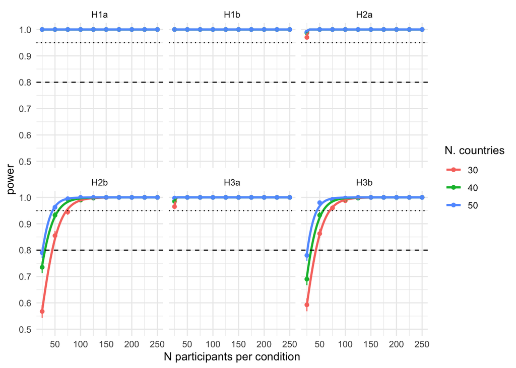

```r
ratio_small <- 0.3

# Reshape the data
data_long <- d %>%
 filter(smaller_fraction == ratio_small) %>%
 gather(key = "hypothesis", value = "value", starts_with("H")) %>%
 filter(!is.na(value))

data_long_avg <- data_long %>%
 group_by(N_tot, N_per_condition, N_countries, hypothesis) %>%
 summarise(
 se_value = binomSEM(value),
 value = mean(value)
 )

# plot split according to number of countries
ggplot(data_long, aes(x = N_per_condition,
                      y = value, color = as.factor(N_countries))) +
 geom_point(data = data_long_avg) +
 geom_errorbar(data = data_long_avg,
               aes(ymin = value-se_value, ymax = value + se_value), width = 0) +
 geom_smooth(method = "glm",
             method.args = list(family = "binomial"), se = FALSE) +
 facet_wrap(~hypothesis) +
 labs(color = "N. countries", x = "N participants per condition", y = "power") +
 geom_hline(yintercept = 0.8, lty = 2) +
 geom_hline(yintercept = 0.95, lty = 3) +
 coord_cartesian(ylim = c(0.5, 1)) +
 theme_minimal()
```

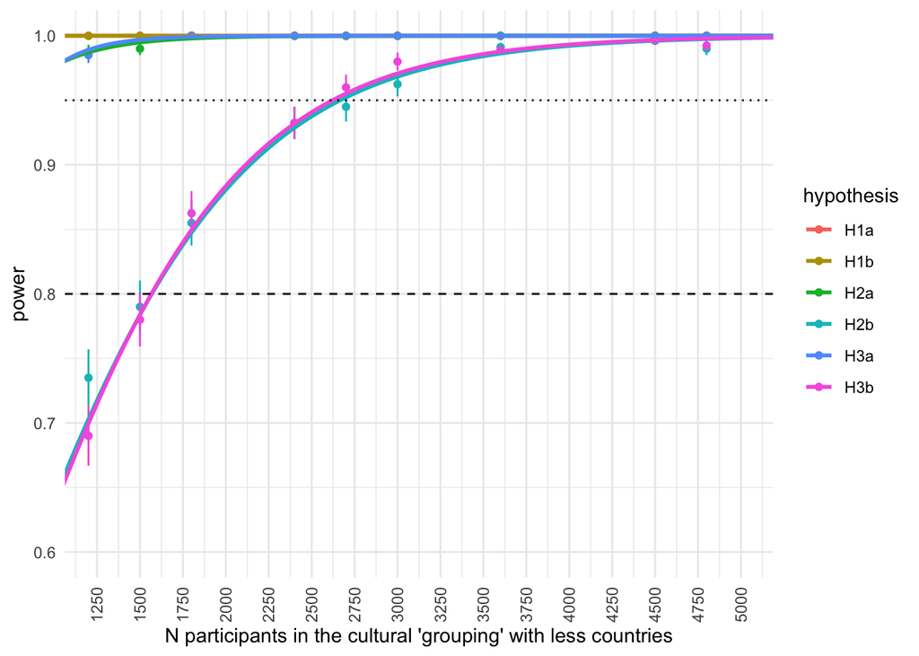

```r
# plot only as a function of number of participants
data_long_avg2 <- data_long %>%
 mutate(N_per_grouping = ratio_small* N_tot) %>%
 group_by(N_per_grouping, hypothesis) %>%
 summarise(
 se_value = binomSEM(value),
 value = mean(value)
 )

data_long <- data_long %>%
 mutate(N_per_grouping = ratio_small* N_tot)

ggplot(data_long, aes(x = N_per_grouping,
                      y = value, color = hypothesis, group = hypothesis)) +
 geom_point(data = data_long_avg2) +
 geom_errorbar(data = data_long_avg2,
               aes(ymin = value-se_value, ymax = value + se_value), width = 0) +
 geom_smooth(method = "glm",
             method.args = list(family = "binomial"), se = FALSE, n = 500) +
 labs(x = "N participants in the cultural 'grouping' with less countries", y = "power") +
 geom_hline(yintercept = 0.8, lty = 2) +
 geom_hline(yintercept = 0.95, lty = 3) +
 coord_cartesian(ylim = c(0.6, 1), xlim = c(1250, 5000)) +
 scale_x_continuous(breaks = seq(0, 10000, 250),
                    guide = guide_axis(angle = 90)) +
 theme_minimal()
```

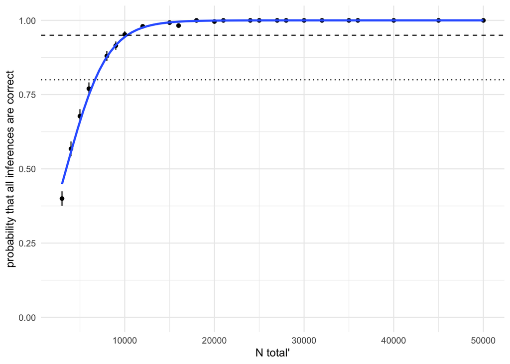

```r
## plot p(all inferences correct)
d$value <- ifelse(d$H1a + d$H1b + d$H2a + d$H2b + d$H3a + d$H3b == 6, 1, 0)

data_avg2 <- d %>%
 filter(smaller_fraction == ratio_small) %>%
 group_by(N_tot) %>%
 summarise(
 se_value = binomSEM(value),
 value = mean(value)
 )

d %>%
 filter(smaller_fraction == ratio_small) %>%
 ggplot(aes(x = N_tot, y = value)) +
 geom_point(data = data_avg2) +
 geom_errorbar(data = data_avg2,
               aes(ymin = value-se_value, ymax = value + se_value), width = 0) +
 geom_smooth(method = "glm",
             method.args = list(family = "binomial"), se = FALSE) +
 geom_hline(yintercept = 0.95, lty = 2) +
 geom_hline(yintercept = 0.8, lty = 3) +
 coord_cartesian(ylim = c(0, 1)) +
 labs(x = "N total'", y = "probability that all inferences are correct") +
 theme_minimal()
```